# Titanic - Casuality Prediction

Ratan Singh

7 December 2017

## Introduction to Dataset

```r
trainData <- read.csv("C:/Users/Ratan Singh/Desktop/R Markdown Files/Titanic Prediction/train.csv",header = TRUE,stringsAsFactors = FALSE)
testData <- read.csv("C:/Users/Ratan Singh/Desktop/R Markdown Files/Titanic Prediction/test.csv",header = TRUE,stringsAsFactors = FALSE)
dim(trainData)
```

```
## [1] 891  12
```

```r
summary(trainData)
```

```
##   PassengerId       Survived          Pclass          Name
##  Min.   :  1.0   Min.   :0.0000   Min.   :1.000   Length:891
##  1st Qu.:223.5   1st Qu.:0.0000   1st Qu.:2.000   Class :character
##  Median :446.0   Median :0.0000   Median :3.000   Mode  :character
##  Mean   :446.0   Mean   :0.3838   Mean   :2.309
##  3rd Qu.:668.5   3rd Qu.:1.0000   3rd Qu.:3.000
##  Max.   :891.0   Max.   :1.0000   Max.   :3.000
##
##      Sex                 Age            SibSp           Parch
##  Length:891         Min.   : 0.42   Min.   :0.000   Min.   :0.0000
##  Class :character   1st Qu.:20.12   1st Qu.:0.000   1st Qu.:0.0000
##  Mode  :character   Median :28.00   Median :0.000   Median :0.0000
##                     Mean   :29.70   Mean   :0.523   Mean   :0.3816
##                     3rd Qu.:38.00   3rd Qu.:1.000   3rd Qu.:0.0000
##                     Max.   :80.00   Max.   :8.000   Max.   :6.0000
##                     NA's   :177
##     Ticket               Fare           Cabin             Embarked
##  Length:891         Min.   :  0.00   Length:891         Length:891
##  Class :character   1st Qu.:  7.91   Class :character   Class :character
##  Mode  :character   Median : 14.45   Mode  :character   Mode  :character
##                     Mean   : 32.20
##                     3rd Qu.: 31.00
##                     Max.   :512.33
##
```

## Selecting the features

Now Let’s recall the details of the incident. When Titanic tragedy took place, it was time of dinner and most of the people were out of the cabins. So basically the parameter **Cabin** Doesn’t make any effect on the survival chances of the people.However if it were a night time when people were asleep, then definitely parameter **Cabin** would have played a crucial role as people with lower cabins would have met their fate first. Also while evacuating the people, they were giving preference to following facts: **(1.) Children over the Adults** **(2.) Women over the Men** **(3.) Class of the Passengers**

Considering Above factors, the parameters **PassengerId, Name, Ticket, Fare, Cabin** and **Embarked** doesn’t any useful information about the survival rate. Now to confirm this hypothesis, we can follow two approaches. We could either compute the correlation of different attributes with the survicval or analyze the attributes graphically to infer their dependence on survival. Before doing this, we must remove above attributes which are useless to our modeling. Also we need to take care of any misisng data.

```r
cleanedTrainData <- trainData[,-c(1,4,9,10,11,12)]
cleanedTestData <- testData[,-c(1,3,8,9,10,11)]
```

Now to check the missing values of the cleaned dataset, we use **is.na()** function. This function when applied to a dataframe returns a boolean dataframe with missing values having bool value **True** and rest as **False**. Now we take columnwise sum of dataset so as to get which column contains how many missing values.

```r
trainMissingValues <- is.na(cleanedTrainData)
print(apply(trainMissingValues,2,sum))
```

```
## Survived   Pclass      Sex      Age    SibSp    Parch
##        0        0        0      177        0        0
```

```r
testMissingValues <- is.na(cleanedTestData)
print(apply(testMissingValues,2,sum))
```

```
## Pclass    Sex    Age  SibSp  Parch
##      0      0     86      0      0
```

Here we can see that only feature that contains missing value is **Age**. One approach is to remove those observations. However their are 177 cases where age is missing and removing them from dataset of 891 observations will result into loss of data. Let’s analyze the pattern of age of the passenger.

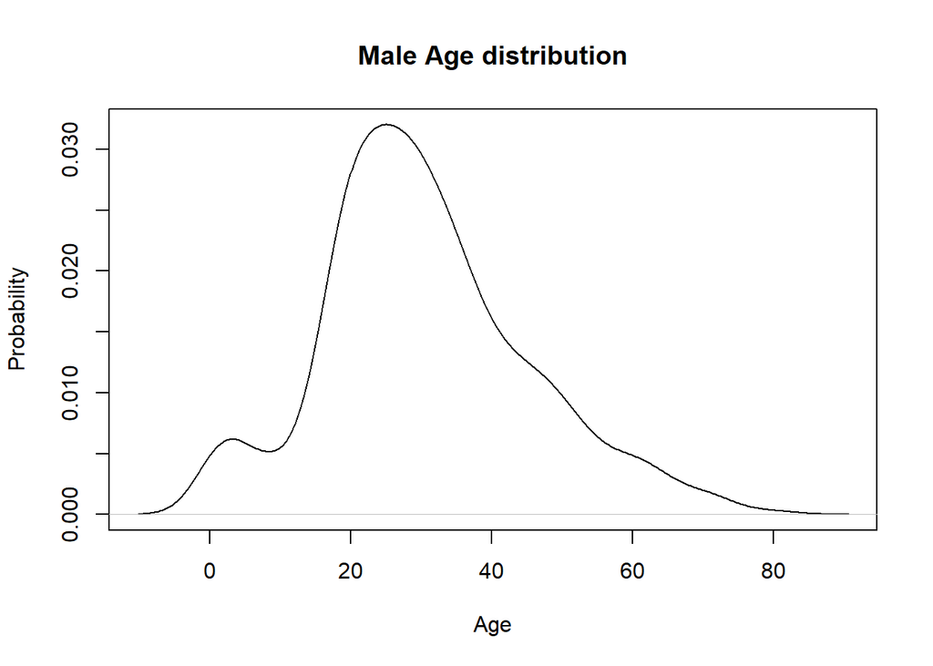

```r
cleanedTrainData$FamilyClass = (cleanedTrainData$SibSp + cleanedTrainData$Parch)*cleanedTrainData$Pclass
cleanedTestData$FamilyClass = (cleanedTestData$SibSp + cleanedTestData$Parch)*cleanedTestData$Pclass

plot(density(cleanedTrainData[cleanedTrainData$Sex == "male",]$Age,na.rm = TRUE),xlab = "Age",ylab = "Probability",main = "Male Age distribution")
```

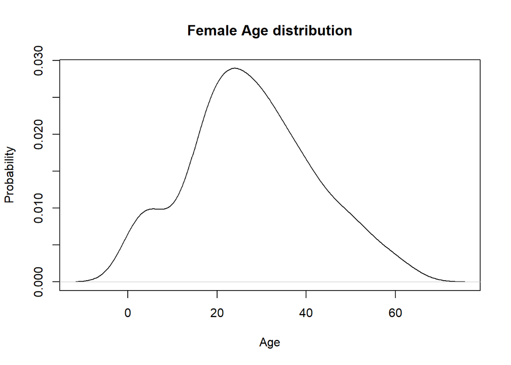

```r
plot(density(cleanedTrainData[cleanedTrainData$Sex == "female",]$Age,na.rm = TRUE),xlab = "Age",ylab = "Probability",main = "Female Age distribution")
```

Here we can see that age distribution is slightly right skewed for both male and female. Hence assigning missing values to the median would be a good approximation than the mean.However there exists a difference in median of both male and female.

```r
medianMaleAgeTrain <- median(cleanedTrainData[cleanedTrainData$Sex == "male",]$Age,na.rm = TRUE)
medianFemaleAgeTrain <- median(cleanedTrainData[cleanedTrainData$Sex == "female",]$Age,na.rm = TRUE)
medianMaleAgeTest <- median(cleanedTestData[cleanedTestData$Sex == "male",]$Age,na.rm = TRUE)
medianFemaleAgeTest <- median(cleanedTestData[cleanedTestData$Sex == "female",]$Age,na.rm = TRUE)

cleanedTrainData[which(cleanedTrainData$Sex == "male" & is.na(cleanedTrainData$Age)),]$Age <- medianMaleAgeTrain
cleanedTrainData[which(cleanedTrainData$Sex == "female" & is.na(cleanedTrainData$Age)),]$Age <- medianFemaleAgeTrain
cleanedTestData[which(cleanedTestData$Sex == "male" & is.na(cleanedTestData$Age)),]$Age <- medianMaleAgeTest
cleanedTestData[which(cleanedTestData$Sex == "female" & is.na(cleanedTestData$Age)),]$Age <- medianFemaleAgeTest
```

Now we have removed the missing data from the both of datasets. Let’s verify the effect of the features on target variable. To do so, we are using Bayesian method. First of all, let’s evaluate the general proportion of people who survived.

```r
prop_genral <- prop.table(table(cleanedTrainData$Survived))
print(prop_genral)
```

```
##
##         0         1
## 0.6161616 0.3838384
```

In general, we can see that 61.61% people died and only 38.38% survived the incident. According to Bayesian Rule, if a feature is correlated with survival rate then it must affect the general probability significantly. Now let’s analyze the effect of gender on the survival rate.

```r
prop_male <- prop.table(table(cleanedTrainData[cleanedTrainData$Sex == "male",]$Survived))
print(prop_male)
```

```
##
##         0         1
## 0.8110919 0.1889081
```

```r
prop_female <- prop.table(table(cleanedTrainData[cleanedTrainData$Sex == "female",]$Survived))
print(prop_female)
```

```
##
##         0         1
## 0.2579618 0.7420382
```

Here we can see that that gender affects the probability of survival greatly as there is a deviation of probability of survival for males and females.Therefore gender is a prominent attribute while considering the survival rate. Now let’s analyze the effect of Age on the survival rate. We are classifying the people below and above 18 years.

```r
prop_kids <- prop.table(table(cleanedTrainData[cleanedTrainData$Age < 18,]$Survived))
print(prop_kids)
```

```
##
##        0        1
## 0.460177 0.539823
```

```r
prop_adult <- prop.table(table(cleanedTrainData[cleanedTrainData$Age >= 18,]$Survived))
print(prop_adult)
```

```
##
##         0         1
## 0.6388175 0.3611825
```

```r
prop_class_1 <- prop.table(table(cleanedTrainData[cleanedTrainData$Pclass == 1,]$Survived))
print(prop_class_1)
```

```
##
##         0         1
## 0.3703704 0.6296296
```

```r
prop_class_2 <- prop.table(table(cleanedTrainData[cleanedTrainData$Pclass == 2,]$Survived))
print(prop_class_2)
```

```
##
##         0         1
## 0.5271739 0.4728261
```

```r
prop_class_3 <- prop.table(table(cleanedTrainData[cleanedTrainData$Pclass == 3,]$Survived))
print(prop_class_3)
```

```
##
##         0         1
## 0.7576375 0.2423625
```

Here we can see that Survival rate of the first class passengers is very high as compared to the general survival rate. Similarly the survival rate of third class passengers is quiet low as compared to the normal death rate.

```r
prop_no_Parch <- prop.table(table(cleanedTrainData[cleanedTrainData$Parch == 0 ,]$Survived))
print(prop_no_Parch)
```

```
##
##         0         1
## 0.6563422 0.3436578
```

```r
prop_with_Parch <- prop.table(table(cleanedTrainData[cleanedTrainData$Parch > 0,]$Survived))
print(prop_with_Parch)
```

```
##
##         0         1
## 0.4882629 0.5117371
```

Similarly we can see that presence of Parent and Child affects the probability of survival rate of passengers. Also Presence of Siblings and spouse affects the survival rate of the passengers Which is visible rom the script below.

```r
prop_no_SibSpo <- prop.table(table(cleanedTrainData[cleanedTrainData$SibSp == 0 ,]$Survived))
print(prop_no_SibSpo)
```

```
##
##         0         1
## 0.6546053 0.3453947
```

```r
prop_with_SibSpo <- prop.table(table(cleanedTrainData[cleanedTrainData$SibSp > 0,]$Survived))
print(prop_with_SibSpo)
```

```
##
##         0         1
## 0.5335689 0.4664311
```

Now we know, that we have chosen correct feature. Now let’s fit a model using various machine learning models. There are multiple algorithms for classification of the target variable. To have a better accuracy, we blend multiple models. The models which we are using here are Logistic Regression, Decision Tree, Support Vector Machine and Neural Network.

```r
set.seed(1)
randomized_Data <-cleanedTrainData[sample(1:nrow(cleanedTrainData),nrow(cleanedTrainData)),]
split_limit <- round(nrow(cleanedTrainData)*0.7)

train_data <- randomized_Data[1:split_limit,]
validation_data <- randomized_Data[(split_limit+1):nrow(cleanedTrainData),]
actual_output <- validation_data[,1]
validation_data <- validation_data[,-1]

Logistic_classifier_model <- glm(Survived ~ ., data = train_data,family = binomial,maxit = 100)
summary(Logistic_classifier_model)
```

```
##
## Call:
## glm(formula = Survived ~ ., family = binomial, data = train_data,
##     maxit = 100)
##
## Deviance Residuals:
##     Min       1Q   Median       3Q      Max
## -2.9944  -0.6181  -0.4293   0.6016   2.4887
##
## Coefficients:
##              Estimate Std. Error z value Pr(>|z|)
## (Intercept)  4.705028   0.600331   7.837 4.60e-15 ***
## Pclass      -0.969478   0.161100  -6.018 1.77e-09 ***
## Sexmale     -2.701765   0.237752 -11.364  < 2e-16 ***
## Age         -0.041976   0.009414  -4.459 8.24e-06 ***
## SibSp        0.446970   0.352434   1.268   0.2047
## Parch        0.604671   0.315574   1.916   0.0554 .
## FamilyClass -0.278703   0.116822  -2.386   0.0170 *
## ---
## Signif. codes:  0 '***' 0.001 '**' 0.01 '*' 0.05 '.' 0.1 ' ' 1
##
## (Dispersion parameter for binomial family taken to be 1)
##
##     Null deviance: 830.57  on 623  degrees of freedom
## Residual deviance: 554.50  on 617  degrees of freedom
## AIC: 568.5
##
## Number of Fisher Scoring iterations: 5
```

```r
predicted_output_Logistic_prob <- predict.glm(Logistic_classifier_model,newdata = validation_data,type = "response")

predicted_output_Logistic <- as.numeric(predicted_output_Logistic_prob >= 0.5)

confusion_matrix_Logistic <- table(predicted_output_Logistic,actual_output)
print(confusion_matrix_Logistic)
```

```
##                          actual_output
## predicted_output_Logistic   0   1
##                         0 146  31
##                         1  18  72
```

```r
TN_log <- confusion_matrix_Logistic[1,1]
FN_log <- confusion_matrix_Logistic[1,2]
FP_log <- confusion_matrix_Logistic[2,1]
TP_log <- confusion_matrix_Logistic[2,2]

accuracy_log <- (TP_log+TN_log)/(TP_log+TN_log+FP_log+FN_log)
precision_log <- TP_log/(TP_log+FP_log)
recall_log <- TP_log/(TP_log+FN_log)
F1_log <- 2*TP_log/(2*TP_log+FP_log+FN_log)
```

Another algorithm for the classification of the two classes is Decision tree model. This model applies simple decision making rules to the parameter and hence creates a tree for the same. This model is more likely to perform good on the datasets where target variable is related lineraly with the attributes.

```r
require(rpart)
Rpart_Classifier_model <- rpart(Survived ~ ., data = train_data, method = "class")
summary(Rpart_Classifier_model)
```

```
## Call:
## rpart(formula = Survived ~ ., data = train_data, method = "class")
##   n= 624
##
##           CP nsplit rel error    xerror       xstd
## 1 0.43096234      0 1.0000000 1.0000000 0.05080882
## 2 0.03138075      1 0.5690377 0.5690377 0.04315083
## 3 0.02510460      3 0.5062762 0.5481172 0.04256660
## 4 0.01000000      4 0.4811715 0.4895397 0.04079498
##
## Variable importance
##         Sex FamilyClass      Pclass       Parch       SibSp         Age
##          51          15          12           8           7           7
##
## Node number 1: 624 observations,    complexity param=0.4309623
##   predicted class=0  expected loss=0.3830128  P(node) =1
##     class counts:   385   239
##    probabilities: 0.617 0.383
##   left son=2 (403 obs) right son=3 (221 obs)
##   Primary splits:
##       Sex         splits as  RL,        improve=83.846450, (0 missing)
##       Pclass      < 2.5   to the right, improve=29.059170, (0 missing)
##       FamilyClass < 0.5   to the left,  improve=15.442810, (0 missing)
##       Parch       < 0.5   to the left,  improve= 7.719017, (0 missing)
##       Age         < 28.25 to the right, improve= 7.514442, (0 missing)
##   Surrogate splits:
##       FamilyClass < 0.5   to the left,  agree=0.691, adj=0.127, (0 split)
##       Parch       < 0.5   to the left,  agree=0.684, adj=0.109, (0 split)
##       SibSp       < 0.5   to the left,  agree=0.667, adj=0.059, (0 split)
##       Age         < 18.5  to the right, agree=0.659, adj=0.036, (0 split)
##
## Node number 2: 403 observations
##   predicted class=0  expected loss=0.191067  P(node) =0.6458333
##     class counts:   326    77
##    probabilities: 0.809 0.191
##
## Node number 3: 221 observations,    complexity param=0.03138075
##   predicted class=1  expected loss=0.2669683  P(node) =0.3541667
##     class counts:    59   162
##    probabilities: 0.267 0.733
```

[output cut: 42 more lines]

```
##   Primary splits:
##       Age         < 27.5  to the right, improve=3.0368860, (0 missing)
##       Parch       < 1.5   to the left,  improve=0.4512450, (0 missing)
##       SibSp       < 0.5   to the right, improve=0.3055846, (0 missing)
##       FamilyClass < 4.5   to the left,  improve=0.2431290, (0 missing)
##
## Node number 26: 18 observations
##   predicted class=0  expected loss=0.3333333  P(node) =0.02884615
##     class counts:    12     6
##    probabilities: 0.667 0.333
##
## Node number 27: 65 observations
##   predicted class=1  expected loss=0.3384615  P(node) =0.1041667
##     class counts:    22    43
##    probabilities: 0.338 0.662
```

```r
predicted_output_RPart <- predict(Rpart_Classifier_model,newdata = validation_data)
predicted_output_RPart_prob <- predicted_output_RPart[,2]

predicted_output_RPart <- as.numeric(predicted_output_RPart_prob >= 0.5)

confusion_matrix_RPart <- table(predicted_output_RPart,actual_output)
print(confusion_matrix_RPart)
```

```
##                       actual_output
## predicted_output_RPart   0   1
##                      0 152  35
##                      1  12  68
```

```r
TN_RPart <- confusion_matrix_RPart[1,1]
FN_RPart <- confusion_matrix_RPart[1,2]
FP_RPart <- confusion_matrix_RPart[2,1]
TP_RPart <- confusion_matrix_RPart[2,2]

accuracy_RPart <- (TP_RPart+TN_RPart)/(TP_RPart+TN_RPart+FP_RPart+FN_RPart)
precision_RPart <- TP_RPart/(TP_RPart+FP_RPart)
recall_RPart <- TP_RPart/(TP_RPart+FN_RPart)
F1_RPart <- 2*TP_RPart/(2*TP_RPart+FP_RPart+FN_RPart)
```

```r
require(e1071)
SVM_Classifier_model <- svm(Survived ~ ., data = train_data)
summary(SVM_Classifier_model)
```

```
##
## Call:
## svm(formula = Survived ~ ., data = train_data)
##
##
## Parameters:
##    SVM-Type:  eps-regression
##  SVM-Kernel:  radial
##        cost:  1
##       gamma:  0.1428571
##     epsilon:  0.1
##
##
## Number of Support Vectors:  301
```

```r
predicted_output_SVM_prob <- predict(SVM_Classifier_model, newdata = validation_data)

predicted_output_SVM <- as.numeric(predicted_output_Logistic_prob >= 0.5)

confusion_matrix_SVM <- table(predicted_output_SVM,actual_output)
print(confusion_matrix_SVM)
```

```
##                     actual_output
## predicted_output_SVM   0   1
##                    0 146  31
##                    1  18  72
```

```r
TN_SVM <- confusion_matrix_SVM[1,1]
FN_SVM <- confusion_matrix_SVM[1,2]
FP_SVM <- confusion_matrix_SVM[2,1]
TP_SVM <- confusion_matrix_SVM[2,2]

accuracy_SVM <- (TP_SVM+TN_SVM)/(TP_SVM+TN_SVM+FP_SVM+FN_SVM)
precision_SVM <- TP_SVM/(TP_SVM+FP_SVM)
recall_SVM <- TP_SVM/(TP_SVM+FN_SVM)
F1_SVM <- 2*TP_SVM/(2*TP_SVM+FP_SVM+FN_SVM)
```

When it comes to non linear features, Neural networks are more effective as compared to the linear algorithm. Unlike previous algorithms, for neural network it becomes effective to normalize the data. An un-normalized data will lead to the hinderance of the weights and will make optimization of the cost function ineffective. Here we have decided to use two hidden layers with hidden units 5 and 3 respectively.

```r
require(neuralnet)
```

```r
randomized_Data_NN <- randomized_Data
randomized_Data_NN[which(randomized_Data_NN$Sex == "male"),]$Sex <- 1
randomized_Data_NN[which(randomized_Data_NN$Sex == "female"),]$Sex <- 0
randomized_Data_NN <- apply(randomized_Data_NN,2,as.numeric)
max_data <- apply(randomized_Data_NN,2,max)
min_data <- apply(randomized_Data_NN,2,min)

randomized_normal_Data <- as.data.frame(scale(randomized_Data_NN,center = min_data,scale = (max_data - min_data)))

train_normal_data <- randomized_normal_Data[1:split_limit,]
validation_normal_data <- randomized_normal_Data[(split_limit+1):nrow(cleanedTrainData),]

neuralnetModel <- neuralnet(Survived ~ Pclass+Sex+Age+SibSp+Parch+FamilyClass, data = train_normal_data,hidden = c(5,3),linear.output = TRUE)
plot(neuralnetModel)

predict_NN_prob = compute(neuralnetModel,validation_normal_data[,-1])$net.result
predict_NN <- as.numeric(predict_NN_prob >= 0.5)
confusion_matrix_NN <- table(predict_NN,actual_output)
print(confusion_matrix_NN)
```

```
##           actual_output
## predict_NN   0   1
##          0 148  29
##          1  16  74
```

```r
TN_NN <- confusion_matrix_NN[1,1]
FN_NN <- confusion_matrix_NN[1,2]
FP_NN <- confusion_matrix_NN[2,1]
TP_NN <- confusion_matrix_NN[2,2]

accuracy_NN <- (TP_NN+TN_NN)/(TP_NN+TN_NN+FP_NN+FN_NN)
precision_NN <- TP_NN/(TP_NN+FP_NN)
recall_NN <- TP_NN/(TP_NN+FN_NN)
F1_NN <- 2*TP_NN/(2*TP_NN+FP_NN+FN_NN)
```

Now Due to inefficiency of each algorithm over some special kind of data points, blending of the models will be a good choice in order to predict such data points. However this method doesn’t guarantee that it will cover all the data points which are affected due to the ineffciency of algorithms. In our case we are blending the results of the four algorithms. There are multiple methods of blending the probabilities. Here we are taking the mean of the probabilities which is simplest of the form.

```r
sum_prob <- predict_NN_prob+predicted_output_Logistic_prob+predicted_output_RPart_prob+predicted_output_SVM_prob
avg_prob <- sum_prob/4
predicted_output <- as.numeric(avg_prob >= 0.5)
confusion_matrix <- table(predicted_output,actual_output)
print(confusion_matrix)
```

```
##                 actual_output
## predicted_output   0   1
##                0 149  26
##                1  15  77
```

```r
TN <- confusion_matrix[1,1]
FN <- confusion_matrix[1,2]
FP <- confusion_matrix[2,1]
TP <- confusion_matrix[2,2]

accuracy <- (TP+TN)/(TP+TN+FP+FN)
precision <- TP/(TP+FP)
recall <- TP/(TP+FN)
F1 <- 2*TP/(2*TP+FP+FN)
```

## Comparative Analysis of each model on basis of different metrics

Following lines of codes print different parameters for each models designed above and hence we can compare the different models depending upon the different applications. Here we are creating a dataframe which contains summary of this metrics.

```r
require(knitr)
summary_table <- NULL

col_names <- c("Model","Accuracy","Precision","Recall","F1")
log_row <- c("Logistic",accuracy_log,precision_log,recall_log,F1_log)
rpart_row <- c("Decision Tree",accuracy_RPart,precision_RPart,recall_RPart,F1_RPart)
svm_row <- c("SVM",accuracy_SVM,precision_SVM,recall_SVM,F1_SVM)
NN_row <- c("Neural Networks",accuracy_NN,precision_NN,recall_NN,F1_NN)
blended_row <- c("Blended Model",accuracy,precision,recall,F1)

summary_table <- rbind(summary_table,log_row,rpart_row,svm_row,NN_row,blended_row)
colnames(summary_table) <- col_names
print(as.data.frame(summary_table))
```

```
##                       Model          Accuracy         Precision
## log_row            Logistic 0.816479400749064               0.8
## rpart_row     Decision Tree 0.823970037453184              0.85
## svm_row                 SVM 0.816479400749064               0.8
## NN_row      Neural Networks 0.831460674157303 0.822222222222222
## blended_row   Blended Model 0.846441947565543  0.83695652173913
##                        Recall                F1
## log_row     0.699029126213592 0.746113989637306
## rpart_row   0.660194174757282 0.743169398907104
## svm_row     0.699029126213592 0.746113989637306
## NN_row      0.718446601941748 0.766839378238342
## blended_row 0.747572815533981  0.78974358974359
```

```r
#prediction on logistic model
predicted_output_Logistic_test_prob <- predict.glm(Logistic_classifier_model,newdata = cleanedTestData,type = "response")

#prediction on decision tree model
predicted_output_RPart_test <- predict(Rpart_Classifier_model,newdata = cleanedTestData)
predicted_output_RPart_test_prob <- predicted_output_RPart_test[,2]

#prediction on SVM model
predicted_output_SVM_test_prob <- predict(SVM_Classifier_model, newdata = cleanedTestData)

#prediction on NN model
testData_NN <- cleanedTestData
testData_NN[which(testData_NN$Sex == "male"),]$Sex <- 1
testData_NN[which(testData_NN$Sex == "female"),]$Sex <- 0
testData_NN <- apply(testData_NN,2,as.numeric)
max_data_test <- apply(testData_NN,2,max)
min_data_test <- apply(testData_NN,2,min)

normal_testData <- as.data.frame(scale(testData_NN,center = min_data_test,scale = (max_data_test - min_data_test)))

predict_NN_test_prob = compute(neuralnetModel,normal_testData)$net.result

# Blending the results
sum_test_prob <- predict_NN_test_prob+predicted_output_Logistic_test_prob+predicted_output_RPart_test_prob+predicted_output_SVM_test_prob
avg_test_prob <- sum_test_prob/4
predicted_output_test <- as.numeric(avg_test_prob >= 0.5)
testData_predicted <- cbind(testData,predicted_output_test)
head(testData_predicted)
```

```
##   PassengerId Pclass                                         Name    Sex
## 1         892      3                             Kelly, Mr. James   male
## 2         893      3             Wilkes, Mrs. James (Ellen Needs) female
## 3         894      2                    Myles, Mr. Thomas Francis   male
## 4         895      3                             Wirz, Mr. Albert   male
## 5         896      3 Hirvonen, Mrs. Alexander (Helga E Lindqvist) female
## 6         897      3                   Svensson, Mr. Johan Cervin   male
##    Age SibSp Parch  Ticket    Fare Cabin Embarked predicted_output_test
## 1 34.5     0     0  330911  7.8292              Q                     0
## 2 47.0     1     0  363272  7.0000              S                     0
## 3 62.0     0     0  240276  9.6875              Q                     0
## 4 27.0     0     0  315154  8.6625              S                     0
## 5 22.0     1     1 3101298 12.2875              S                     1
## 6 14.0     0     0    7538  9.2250              S                     0
```